# Reproducibility of Centiloids

UCSF; version 2.05

2026-01-27

# Cohort: Demo

## Chapter I: Gaussian Mixture Models

#### Optimal number of components in GMM [1-5]

[output not shown]

#### GMM for CL distribution [random initialization, bootstrap, ECM algorithm]

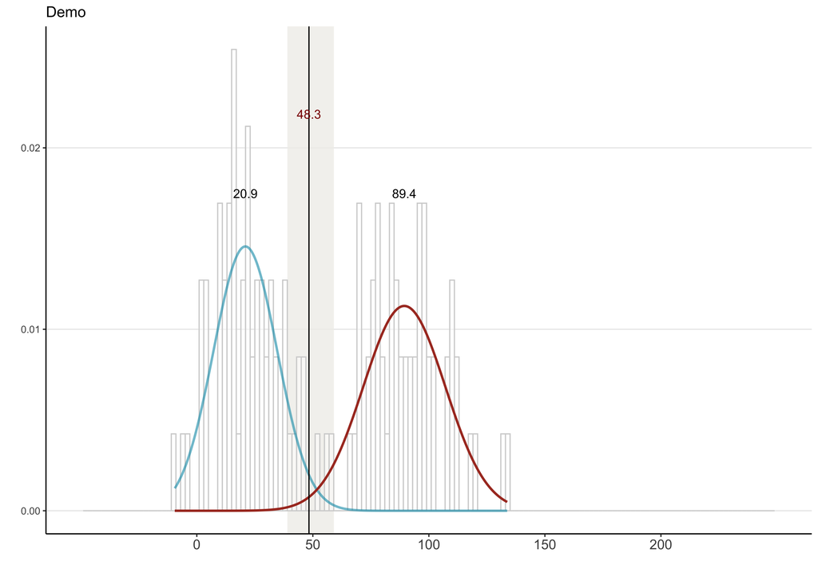

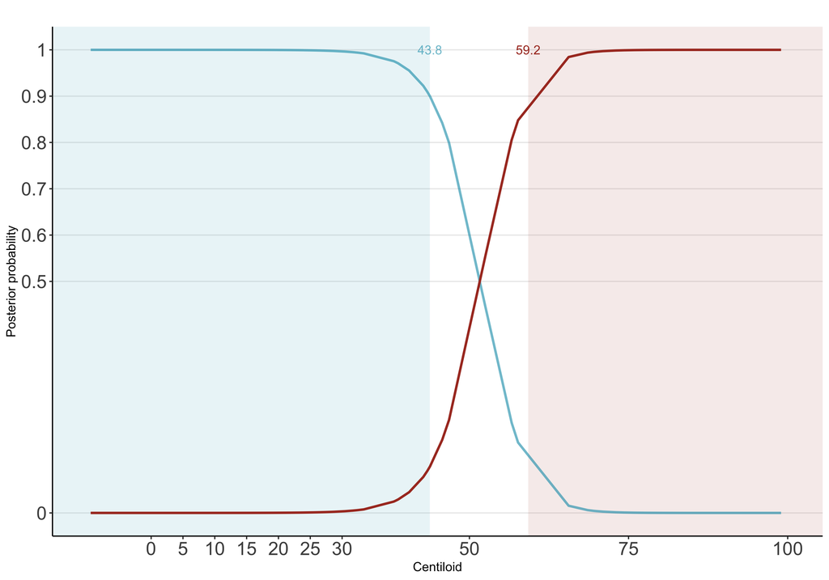

|  | Clearly negative cutoff | Clearly positive cutoff |
| --- | --- | --- |
| Posterior probability [cutoff] = 0.50 | 51.71 | 51.72 |
| Posterior probability [cutoff] = 0.60 | 50.25 | 53.18 |
| Posterior probability [cutoff] = 0.70 | 48.68 | 54.72 |
| Posterior probability [cutoff] = 0.80 | 46.78 | 56.53 |
| Posterior probability [cutoff] = 0.90 | 43.79 | 59.24 |

## Chapter II: Correspondence between quantification and visual read

#### Cutoff based on maximizing kappa: correspondance between visual read and quantification

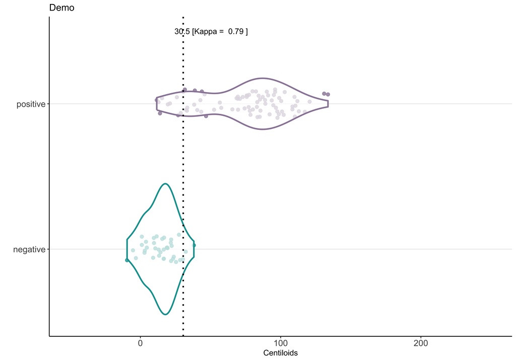

#### Cutoff based on ROC AUC analysis with Youden index

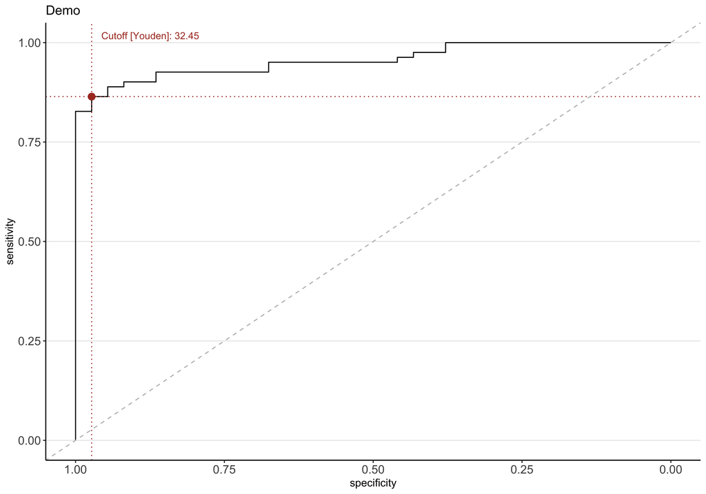

## Chapter III: Association with non-imaging data

#### Association with age and sex

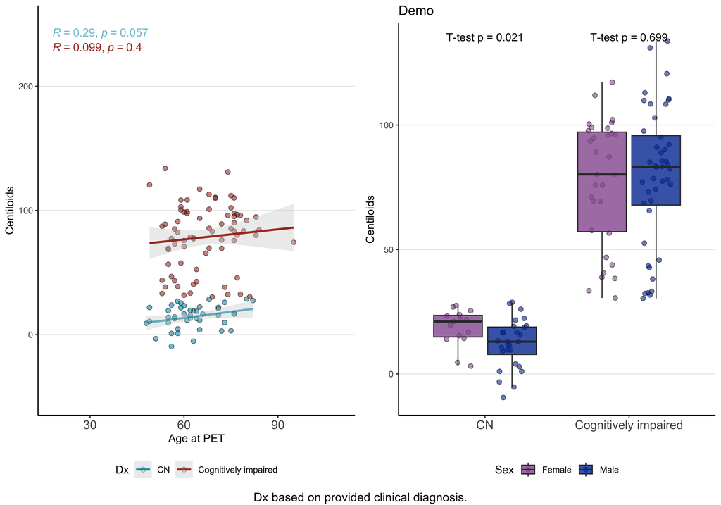

```
## Centiloid by age association: Pearson r - 0.228, p-value - 0.0131.
## Centiloid by age association: intercept -  -5.033, slope - 0.921, p-value - 0.0131.
## Centiloid by age association in CN: Pearson r - 0.292, p-value - 0.0574.
## Centiloid by age association in Cognitively Impaired: Pearson r - 0.099, p-value - 0.399.
## Centiloid by age association in CN: intercept -  -6.199, slope - 0.328, p-value - 0.0574.
## Centiloid by age association in Cognitively Impaired: intercept -  60.405, slope - 0.271, p-value - 0.399.
## Centiloid in males vs. females: T-value - 0.677, p-value - 0.5.
## Centiloid in males vs. females in CN: T-value - 2.423, p-value - 0.0205.
## Centiloid in males vs. females in Cognitively Impaired: T-value - -0.388, p-value - 0.699.
```

#### Association with cognitive scores

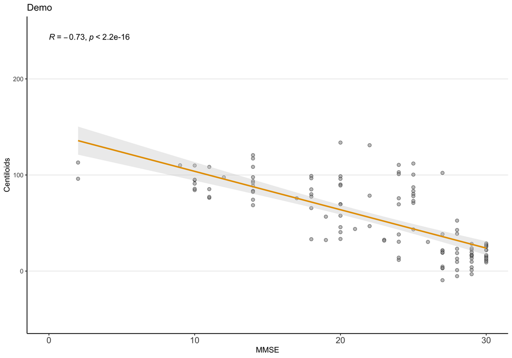

```
## Centiloid by MMSE association: intercept -  143.74, slope - -3.994, p-value - <2e-16.
```

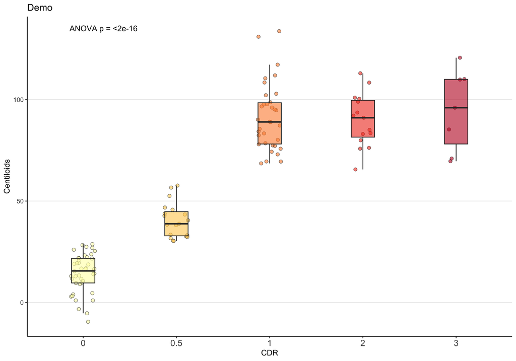

```
## Centiloid by CDR, Tukey HSD difference [p-value]:
##   Tukey multiple comparisons of means
##     95% family-wise confidence level
##
## Fit: aov(formula = cl ~ as.factor(cdr), data = data_clean)
##
## $`as.factor(cdr)`
##            diff       lwr       upr     p adj
## 0.5-0 26.025377  16.14392 35.906832 0.0000000
## 1-0   76.938691  68.70665 85.170736 0.0000000
## 2-0   75.388441  64.63196 86.144921 0.0000000
## 3-0   80.192818  65.57314 94.812496 0.0000000
## 1-0.5 50.913314  40.63888 61.187743 0.0000000
## 2-0.5 49.363063  36.97358 61.752543 0.0000000
## 3-0.5 54.167441  38.30767 70.027211 0.0000000
## 2-1   -1.550251 -12.66882  9.568321 0.9952089
## 3-1    3.254127 -11.63398 18.142234 0.9738959
## 3-2    4.804378 -11.61485 21.223606 0.9267052
```

#### Association with APOE E4

```
## Centiloid by APOE4 status, Tukey HSD difference:
##                                              diff        lwr      upr     p adj
## Heterozygous-Carrier-Non-Carrier        15.299575  -4.322604 34.92175 0.1571343
## Homozygous-Carrier-Non-Carrier           5.869364 -22.021809 33.76054 0.8709786
## Homozygous-Carrier-Heterozygous-Carrier -9.430211 -36.990741 18.13032 0.6948805
```

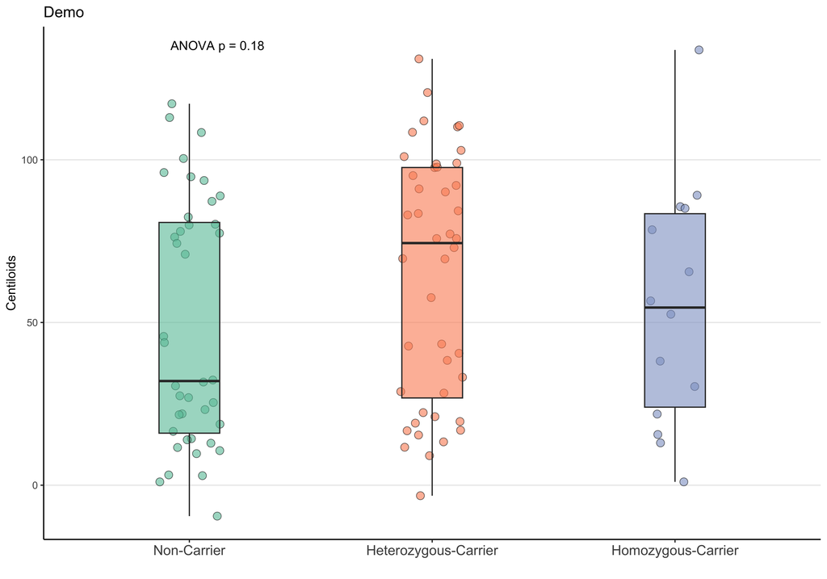

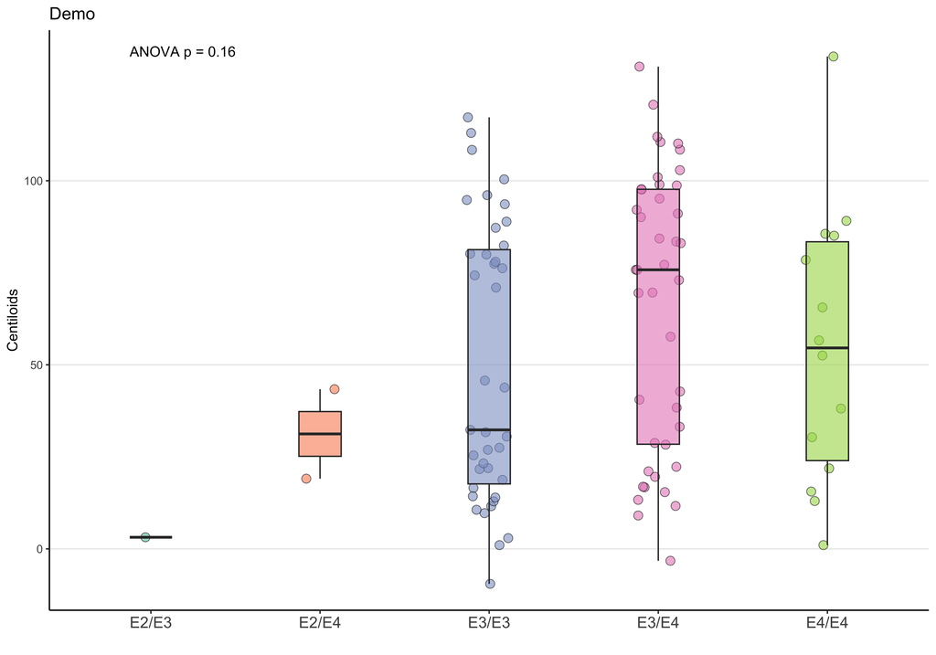

```
##                   diff        lwr       upr     p adj
## E2/E4-E2/E3  28.072604 -99.691256 155.83646 0.9729808
## E3/E3-E2/E3  46.911610 -58.736099 152.55932 0.7308122
## E3/E4-E2/E3  62.608194 -42.945144 168.16153 0.4697130
## E4/E4-E2/E3  51.608184 -56.371985 159.58835 0.6735474
## E3/E3-E2/E4  18.839006 -56.793243  94.47126 0.9575486
## E3/E4-E2/E4  34.535591 -40.964780 110.03596 0.7085772
## E4/E4-E2/E4  23.535581 -55.321985 102.39315 0.9205617
## E3/E4-E3/E3  15.696584  -7.501277  38.89445 0.3339888
## E4/E4-E3/E3   4.696574 -27.804971  37.19812 0.9944094
## E4/E4-E3/E4 -11.000010 -43.193477  21.19346 0.8761657
```

## Summary

Full Cohort

FBB

FBP

**Cohort Description**

N

118

58

60

Age (mean, y)

65.33

64.71

65.93

Age (SD, y)

9.37

9.58

9.19

Sex (N male)

72

35

37

Available visual read (N)

118

58

60

Cognitively unimpaired (N)

43

Cognitively impaired (N)

75

Cognitively unimpaired male (N)

28

Cognitively unimpaired female (N)

15

Cognitively impaired male (N)

44

Cognitively impaired female (N)

31

**Genetic Data**

Available APOE (N)

98

48

50

APOE4 Non-Carriers (N)

40

24

16

APOE4 Homozygous Carriers (N)

14

6

8

APOE4 Heterozygous Carriers (N)

44

18

26

APOE4 CU Non-Carriers (N)

18

APOE4 CU Homozygous Carriers (N)

4

APOE4 CU Heterozygous Carriers (N)

13

APOE4 CI Non-Carriers (N)

22

APOE4 CI Homozygous Carriers (N)

10

APOE4 CI Heterozygous Carriers (N)

31

**Clinical Data**

Available Dx (N)

118

58

60

Controls (N)

43

22

21

MCI (N)

19

11

8

Dementia (N)

56

25

31

Available CDR (N)

118

58

60

Controls (CDR = 0, N)

43

22

21

Patient (CDR >= 0.5, N)

75

36

39

CDR (mean)

0.80

0.72

0.88

CDR (SD)

0.86

0.78

0.92

Available MMSE (N)

118

58

60

MMSE (mean)

22.18

22.33

22.03

MMSE (SD)

6.93

6.68

7.22

**GMM Results**

G1 mean (CL)

20.93

21.01

19.03

G1 mean 95%CI lower bound (CL)

16.55

14.64

13.79

G1 mean 95%CI upper bound (CL)

26.62

27.39

55.53

G2 mean (CL)

89.41

90.22

86.34

G2 mean 95%CI lower bound (CL)

82.95

62.73

72.41

G2 mean 95%CI upper bound (CL)

94.36

95.27

97.27

G1 SD (CL)

13.70

14.89

10.25

G1 SD 95%CI lower bound (CL)

10.40

8.23

4.70

G1 SD 95%CI upper bound (CL)

17.40

18.46

37.53

G2 SD (CL)

17.67

12.23

22.81

G2 SD 95%CI lower bound (CL)

12.82

8.53

4.26

G2 SD 95%CI upper bound (CL)

22.84

34.05

31.27

GMM Cutoff (CL)

48.33

50.79

39.52

GMM Cutoff 95%CI lower bound (CL)

39.02

37.55

25.19

GMM Cutoff 95%CI upper bound (CL)

59.04

60.42

130.43

GMM Cutoff Clearly Negative P=0.50 (CL)

51.71

57.77

41.23

GMM Cutoff Clearly Negative P=0.50 95%CI lower bound (CL)

42.06

33.74

25.85

GMM Cutoff Clearly Negative P=0.50 95%CI upper bound (CL)

60.93

64.78

99.16

GMM Cutoff Clearly Positive P=0.50 (CL)

51.72

57.78

41.24

GMM Cutoff Clearly Positive P=0.50 95%CI lower bound (CL)

42.37

35.22

26.30

GMM Cutoff Clearly Positive P=0.50 95%CI upper bound (CL)

60.94

64.79

95.11

GMM Cutoff Clearly Negative P=0.60 (CL)

50.25

56.20

39.84

GMM Cutoff Clearly Negative P=0.60 95%CI lower bound (CL)

40.62

31.98

24.98

GMM Cutoff Clearly Negative P=0.60 95%CI upper bound (CL)

59.50

62.58

99.90

GMM Cutoff Clearly Positive P=0.60 (CL)

53.18

59.36

42.58

GMM Cutoff Clearly Positive P=0.60 95%CI lower bound (CL)

43.78

37.15

27.43

GMM Cutoff Clearly Positive P=0.60 95%CI upper bound (CL)

62.58

66.83

95.99

GMM Cutoff Clearly Negative P=0.70 (CL)

48.68

54.57

38.28

GMM Cutoff Clearly Negative P=0.70 95%CI lower bound (CL)

38.92

29.10

23.79

GMM Cutoff Clearly Negative P=0.70 95%CI upper bound (CL)

57.87

60.14

100.23

GMM Cutoff Clearly Positive P=0.70 (CL)

54.72

61.02

43.99

GMM Cutoff Clearly Positive P=0.70 95%CI lower bound (CL)

45.18

38.46

28.40

GMM Cutoff Clearly Positive P=0.70 95%CI upper bound (CL)

64.19

69.01

95.50

GMM Cutoff Clearly Negative P=0.80 (CL)

46.78

52.78

36.27

GMM Cutoff Clearly Negative P=0.80 95%CI lower bound (CL)

36.86

25.04

22.45

GMM Cutoff Clearly Negative P=0.80 95%CI upper bound (CL)

56.02

57.48

102.31

GMM Cutoff Clearly Positive P=0.80 (CL)

56.53

62.86

45.74

GMM Cutoff Clearly Positive P=0.80 95%CI lower bound (CL)

46.96

40.07

29.75

GMM Cutoff Clearly Positive P=0.80 95%CI upper bound (CL)

66.15

71.26

95.75

GMM Cutoff Clearly Negative P=0.90 (CL)

43.79

50.63

33.00

GMM Cutoff Clearly Negative P=0.90 95%CI lower bound (CL)

33.79

22.86

19.59

GMM Cutoff Clearly Negative P=0.90 95%CI upper bound (CL)

53.49

53.96

103.54

GMM Cutoff Clearly Positive P=0.90 (CL)

59.24

65.17

48.26

GMM Cutoff Clearly Positive P=0.90 95%CI lower bound (CL)

49.46

42.05

31.07

GMM Cutoff Clearly Positive P=0.90 95%CI upper bound (CL)

69.15

73.95

96.77

**Correspondence to Visual Read**

Kappa-based Cutoff (CL)

30.52

26.01

28.77

Kappa-based Cutoff 95%CI lower bound (CL)

26.01

26.01

19.57

Kappa-based Cutoff 95%CI upper bound (CL)

38.81

38.81

52.53

Max Kappa

0.79

0.85

0.81

Max Kappa 95%CI lower bound

0.70

0.72

0.65

Max Kappa 95%CI upper bound

0.91

0.97

0.96

ROC-based Cutoff [Youden] (CL)

32.45

25.70

28.54

ROC-based Cutoff [Youden] 95%CI lower bound (CL)

25.36

24.16

26.28

ROC-based Cutoff [Youden] 95%CI upper bound (CL)

39.32

35.57

45.33

ROC-based AUC

0.96

0.97

0.95

ROC-based AUC 95% CI lower bound

0.92

0.92

0.89

ROC-based AUC 95% CI upper bound

0.99

1.00

1.00

ROC-based Cutoff [95%-sens] (CL)

19.46

13.64

19.16

ROC-based Cutoff [95%-sens] 95%CI lower bound (CL)

12.29

10.68

8.76

ROC-based Cutoff [95%-sens] 95%CI upper bound (CL)

30.23

31.01

30.97

ROC-based Cutoff [95%-spec] (CL)

32.45

32.88

40.43

ROC-based Cutoff [95%-spec] 95%CI lower bound (CL)

25.70

24.32

26.28

ROC-based Cutoff [95%-spec] 95%CI upper bound (CL)

39.32

35.57

47.38

ROC-based Cutoff [90%-sens] (CL)

28.54

26.46

28.54

ROC-based Cutoff [90%-sens] 95%CI lower bound (CL)

18.23

12.81

14.16

ROC-based Cutoff [90%-sens] 95%CI upper bound (CL)

38.24

36.12

45.33

ROC-based Cutoff [90%-spec] (CL)

28.54

30.42

28.54

ROC-based Cutoff [90%-spec] 95%CI lower bound (CL)

23.52

22.55

22.87

ROC-based Cutoff [90%-spec] 95%CI upper bound (CL)

32.88

35.34

45.33

Positive visual read (N)

81

38

43

Negative visual read (N)

37

20

17

**Quantification by feature**

CL in males (mean)

53.32

47.08

59.23

CL in females (mean)

58.03

56.34

59.72

CL in males (SD)

39.84

38.28

40.90

CL in females (SD)

34.81

35.75

34.57

CL in CU males (mean)

12.22

CL in CU females (mean)

18.64

CL in CU males (SD)

9.77

CL in CU females (SD)

7.36

CL in CI males (mean)

79.48

CL in CI females (mean)

77.09

CL in CI males (SD)

27.58

CL in CI females (SD)

25.33

CL in APOE4 Non-Carriers (mean)

48.89

49.70

47.68

CL in APOE4 Non-Carriers (SD)

37.73

39.21

36.62

CL in APOE4 Homozygous Carriers (mean)

54.76

35.05

69.55

CL in APOE4 Homozygous Carriers (SD)

37.31

30.53

36.56

CL in APOE4 Heterozygous Carriers (mean)

64.19

56.31

69.65

CL in APOE4 Heterozygous Carriers (SD)

37.84

38.24

37.32

CL in CU APOE4 Non-Carriers (mean)

14.03

CL in CU APOE4 Non-Carriers (SD)

10.04

CL in CU APOE4 Homozygous Carriers (mean)

12.86

CL in CU APOE4 Homozygous Carriers (SD)

8.73

CL in CU APOE4 Heterozygous Carriers (mean)

16.84

CL in CU APOE4 Heterozygous Carriers (SD)

8.36

CL in CI APOE4 Non-Carriers (mean)

77.41

CL in CI APOE4 Non-Carriers (SD)

25.84

CL in CI APOE4 Homozygous Carriers (mean)

71.52

CL in CI APOE4 Homozygous Carriers (SD)

29.89

CL in CI APOE4 Heterozygous Carriers (mean)

84.05

CL in CI APOE4 Heterozygous Carriers (SD)

25.41

CL in positive visual read (mean)

73.61

70.57

76.29

CL in positive visual read (SD)

30.74

29.99

31.50

CL in negative visual read (mean)

14.76

13.08

16.74

CL in negative visual read (SD)

10.92

11.60

10.04

CDR=0 (N)

43

22

21

CDR=0.5 (N)

19

11

8

CDR>=1 (N)

56

25

31

CL in CDR=0 (mean)

14.46

12.61

16.39

CL in CDR=0.5 (mean)

40.48

37.45

44.65

CL in CDR>=1 (mean)

91.39

90.16

92.38

CL in CDR=0 (SD)

9.43

10.34

8.18

CL in CDR=0.5 (SD)

8.56

6.14

10.00

CL in CDR>=1 (SD)

15.94

12.50

18.40

**Associations**

Correlation age-CL (rho)

0.23

Correlation age-CL (p-value)

0.01

Correlation age-CL in CU (rho)

0.29

Correlation age-CL in CU (p-value)

0.06

Correlation age-CL in CI (rho)

0.1

Correlation age-CL in CI (p-value)

0.4

Correlation MMSE-CL (rho)

-0.73

Correlation MMSE-CL (p-value)

0

This report was generated on 2026-01-27 13:50:10. Code created by Ganna Blazhenets; ganna.blazhenets @ ucsf.edu.